# IE582-Homework4

Random forest is performed to predict class information. Firstly, I generated a model with mtry=5 and examine the OOB error and class errors.After that, mtry parameter is tuned using “tuneRF” function. Different mtry levels are considered and the best mtry is selected using OOB(out-of-bag) error. In this case,mtry=4 gives the minimum OOB error and model is generated using this value.

```r
library(randomForest)
train.class = factor(train.class)
model1 <- randomForest(train.class ~ ., data = traindata, ntree = 500,
    mtry = 5, nodesize = 5)
model1
```

```
##
## Call:
##  randomForest(formula = train.class ~ ., data = traindata, ntree = 500,      mtry = 5, nodesize = 5)
##                Type of random forest: classification
##                      Number of trees: 500
## No. of variables tried at each split: 5
##
##         OOB estimate of  error rate: 14.48%
## Confusion matrix:
##     0  1 class.error
## 0 857 12  0.01380898
## 1 137 23  0.85625000
```

```r
# Execute the tuning process
set.seed(123)
res <- tuneRF(x = traindata, y = train.class, mtryStart = 1,
    ntreeTry = 500, stepFactor = 2, improve = 0.01)
```

```
## mtry = 1  OOB error = 15.55%
## Searching left ...
## Searching right ...
## mtry = 2     OOB error = 15.06%
## 0.03125 0.01
## mtry = 4     OOB error = 14.48%
## 0.03870968 0.01
## mtry = 8     OOB error = 14.87%
## -0.02684564 0.01
```

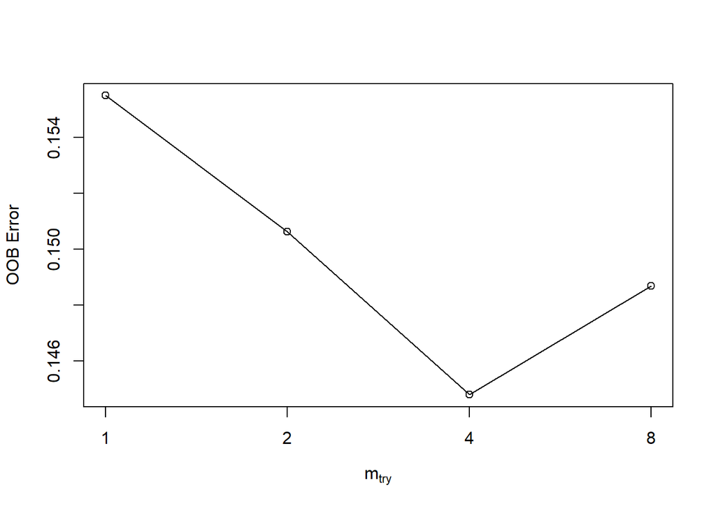

```r
# Look at results
print(res)
```

```
##       mtry  OOBError
## 1.OOB    1 0.1554908
## 2.OOB    2 0.1506317
## 4.OOB    4 0.1448008
## 8.OOB    8 0.1486880
```

```r
# Find the mtry value that minimizes OOB Error
mtry_opt <- res[, "mtry"][which.min(res[, "OOBError"])]
print(mtry_opt)
```

```
## 4.OOB
##     4
```

```r
model2 <- randomForest(train.class ~ ., data = traindata, ntree = 500,
    mtry = 4, nodesize = 5)
model2
```

```
##
## Call:
##  randomForest(formula = train.class ~ ., data = traindata, ntree = 500,      mtry = 4, nodesize = 5)
##                Type of random forest: classification
##                      Number of trees: 500
## No. of variables tried at each split: 4
##
##         OOB estimate of  error rate: 14.58%
## Confusion matrix:
##     0  1 class.error
## 0 858 11  0.01265823
## 1 139 21  0.86875000
```

```r
pred <- predict(model2, traindata)
confusionMatrix(pred, train.class)
```

```
## Confusion Matrix and Statistics
##
##           Reference
## Prediction   0   1
##          0 869  28
##          1   0 132
##
##                Accuracy : 0.9728
##                  95% CI : (0.9609, 0.9818)
##     No Information Rate : 0.8445
##     P-Value [Acc > NIR] : < 2.2e-16
##
##                   Kappa : 0.8884
##  Mcnemar's Test P-Value : 3.352e-07
##
##             Sensitivity : 1.0000
##             Specificity : 0.8250
##          Pos Pred Value : 0.9688
##          Neg Pred Value : 1.0000
##              Prevalence : 0.8445
##          Detection Rate : 0.8445
##    Detection Prevalence : 0.8717
##       Balanced Accuracy : 0.9125
##
##        'Positive' Class : 0
##
```

```r
pred <- predict(model2, testdata)
confusionMatrix(pred, factor(test.class))
```

```
## Confusion Matrix and Statistics
##
##           Reference
## Prediction   0   1
##          0 361  64
##          1   3  13
##
##                Accuracy : 0.8481
##                  95% CI : (0.8111, 0.8803)
##     No Information Rate : 0.8254
##     P-Value [Acc > NIR] : 0.1154
##
##                   Kappa : 0.2335
##  Mcnemar's Test P-Value : 2.299e-13
##
##             Sensitivity : 0.9918
##             Specificity : 0.1688
##          Pos Pred Value : 0.8494
##          Neg Pred Value : 0.8125
##              Prevalence : 0.8254
##          Detection Rate : 0.8186
##    Detection Prevalence : 0.9637
##       Balanced Accuracy : 0.5803
##
##        'Positive' Class : 0
##
```

**5-Gradient Boosting Machine**

Lastly, gradient boosting machine algorithm is used to predict classes Grid search which iterates over every combination of hyperparameter is performed to assess which combination tends to perform well.Number of trees,learning rates and tree depth paramters are tuned for this purpose. While trying every combination, cross validation and train error are considered to choose the best parameters.

Since R session is aborted while evaluating this code chunk, I could not show the results. Therefore, only the codes are available below.

```r
library(gbm)
library(data.table)
library(caret)
library(dplyr)

traindata = traindata[, -5]
testdata = testdata[, -5]

# create hyperparameter grid
hyper_grid <- expand.grid(n.trees = c(1000, 5000), shrinkage = c(0.01,
    0.1, 0.3), interaction.depth = c(1, 5))

optimal_trees = rep(NA, nrow(hyper_grid))  # a place to dump results
min_train_error = rep(NA, nrow(hyper_grid))
min_cv_error = rep(NA, nrow(hyper_grid))  # a place to dump results


# grid search
for (i in 1:nrow(hyper_grid)) {

    # reproducibility
    set.seed(123)
    # train model
    gbm.tune <- gbm(train.class ~ ., distribution = "bernoulli",
        data = traindata, n.trees = hyper_grid$n.trees[i], interaction.depth = hyper_grid$interaction.depth[i],
        shrinkage = hyper_grid$shrinkage[i], cv.folds = 10, n.minobsinnode = 10)
    # add min training error and trees to grid
    optimal_trees[i] <- which.min(gbm.tune$cv.error)
    min_train_error[i] <- sqrt(min(gbm.tune$train.error))
    min_cv_error[i] <- sqrt(min(gbm.tune$cv.error))
}


cbind(hyper_grid, optimal_trees, min_train_error, min_cv_error) %>%
    dplyr::arrange(min_cv_error) %>% head(10)

gbm.fit <- gbm(train.class ~ ., distribution = "bernoulli", data = traindata,
    n.trees = 5000, interaction.depth = 3, shrinkage = 0.1, cv.folds = 10,
    n.minobsinnode = 10)

pred <- predict(gbm.fit, traindata, type = "response")

prediction_res = ifelse(pred < 0.5, 0, 1)
confusionMatrix(factor(prediction_res), factor(train.class))

testdata = testdata[, -5]
pred <- predict(gbm.fit, testdata)
prediction_res = ifelse(pred < 0.5, 0, 1)
confusionMatrix(factor(prediction_res), factor(test.class))
```

[output not shown]